# Practical Machine Learning Course

Project Activity Recognition Analysis

Larry Lugo

August, 2015

## 0.1 Introduction and background

Nowadays, using devices such as Jawbone Up, Nike FuelBand, and Fitbit it is possible to collect a large amount of data about personal activity relatively inexpensively. One thing that people regularly do is quantify how much of a particular activity they do, but they rarely quantify how well they do it. The goal of this project is to predict the manner in which 6 participants did the exercise. This document describes the process analysis applied.

## 0.2 Data Source and Description

The data for this project comes from this [source](http://groupware.les.inf.puc-rio.br/har) and includes information collected by accelerometers on the belt, forearm, arm, and dumbell of 6 participants. They were asked to perform barbell lifts correctly and incorrectly in 5 different ways (please see the section on the Weight Lifting Exercise Dataset). These type of devices are part of the quantified self movement - a group of enthusiasts who take measurements about themselves regularly to improve their health.

## 0.3 Process Analysis

### 0.3.1 Exploring and Cleaning Data

The first step is to explore the data, in particular for missing values (NAs). A minimum threshold of 75% of complete data to retain a variable (column) was established in the whole training set of values. If were smaller, it was removed:

```r
#Set working directory
setwd('C:/Users/Larry/DataScience-Coursera/PracticalMachineLearning/Project')
#Read training csv file and delete first row with columns' name
raw.pml.train <- read.csv('pml-training.csv', header=TRUE, sep=",", na.strings=c("NA",""))
raw.pml.train <- raw.pml.train[,-1]
#Columns with data < 75%
tot.col.nas.train <- sum((colSums(!is.na(raw.pml.train[,-ncol(raw.pml.train)])) < 0.75*nrow(raw.pml.train)))
```

A total of 100 columns have less than 75% complete values. So, they were deleted:

```r
keep.cols <- c((colSums(!is.na(raw.pml.train [,-ncol(raw.pml.train )])) >= 0.75*nrow(raw.pml.train )))
pml.train <- raw.pml.train[,keep.cols]
```

### 0.3.2 Splitting Data for Cross Validation

Using the standard procedures studied on course, data was divided into training (60%) and testing (40%):

```r
set.seed(135)
#Load required libraries
library(lattice)
library(ggplot2)
library(caret)
library(e1071)
library(gbm)
library(rattle)
#Splitting data
inTrain <- createDataPartition(y=pml.train$classe, p=0.6, list=FALSE)
training <- pml.train[inTrain,]
testing <- pml.train[-inTrain,]
```

### 0.3.3 Fitting the model

```r
#Fitting the model using "gbm" method
modFit <- train(classe ~ user_name + pitch_arm + yaw_arm + roll_arm + roll_belt + pitch_belt + yaw_belt + gyros_belt_x + gyros_belt_y + gyros_belt_z + accel_belt_x + accel_belt_y + accel_belt_z + magnet_belt_x + magnet_belt_y + magnet_belt_z + gyros_arm_x + gyros_arm_y + gyros_arm_z + accel_arm_x + accel_arm_y + accel_arm_z + magnet_arm_x + magnet_arm_y + magnet_arm_z + roll_dumbbell + pitch_dumbbell + yaw_dumbbell, method="gbm", data=training, verbose=FALSE)
print(modFit)
```

[output not shown]

```r
predictTrain <- predict(modFit,training)
table(predictTrain, training$classe)
```

```
##
## predictTrain    A    B    C    D    E
##            A 3165   98   34   14   23
##            B   42 2095   75   12   18
##            C   49   71 1898  100   17
##            D   70    7   43 1791   13
##            E   22    8    4   13 2094
```

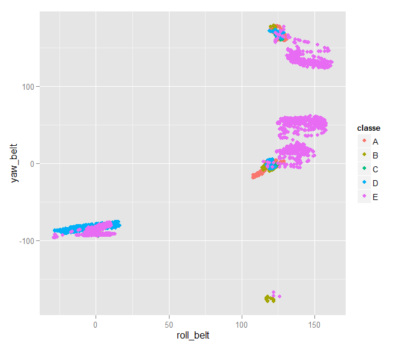

```r
qplot(roll_belt,yaw_belt,color=classe,data=training)
```

Besides that, both variables are not enough to classify observations only by themselves, confirming that the **gbm** method was a right approach.

On the other hand, using *Boosting Iterations* improves model’s performance:

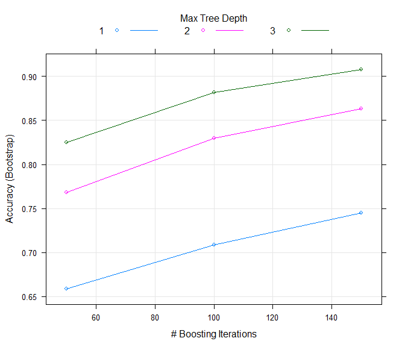

```r
plot(modFit)
```

### 0.3.4 Out of Sample Performance

The out-of-sample performance of the fitted model was evaluated using the 40% sub-sample testing set, obtained from the cleaned (without NA’s) training set:

```r
predictTest <- predict(modFit,testing)
```

The algorithm correctly classified 91.9576854 % of the observations on the testing set, performing a little worse than the training set.

## 0.4 Predicting on the Test Set

The final stage is to use the algorithm on the testing set (pml-testing.csv) containing the activities of 6 participants, in order to identify them as A, B, C, D or E, and generates the corresponding text files to be uploaded using the function “pml_write_files()” provided by course staff.

```r
pml.testing <- read.csv('pml-testing.csv')
answers <- as.character(predict(modFit, pml.testing))
pml_write_files = function(x){
  n = length(x)
  for(i in 1:n){
    filename = paste0("problem_id_",i,".txt")
write.table(x[i],file=filename,quote=FALSE,row.names=FALSE,col.names=FALSE)
  }
}
pml_write_files(answers)
```

## 0.5 Conclusion

As showed by the automatic correction of the assignment in the course site, a total of 20/20 right predictions for the type of activity was obtained, indicating that the algorithm’s performance is very accurate.

## 0.6 References

Ugulino, W.; Cardador, D.; Vega, K.; Velloso, E.; Milidiu, R.; Fuks, H. Wearable Computing: Accelerometers’ Data Classification of Body Postures and Movements. Proceedings of 21st Brazilian Symposium on Artificial Intelligence. Advances in Artificial Intelligence - SBIA 2012. In: Lecture Notes in Computer Science. , pp. 52-61. Curitiba, PR: Springer Berlin / Heidelberg, 2012. ISBN 978-3-642-34458-9. DOI: 10.1007/978-3-642-34459-6_6.

Read more: http://groupware.les.inf.puc-rio.br/har#ixzz3jg5fqtvw